# Data visualization: Introduction

### Scatterplot: size

Используйте параметр size в эстетике, чтобы отобразить возраст:

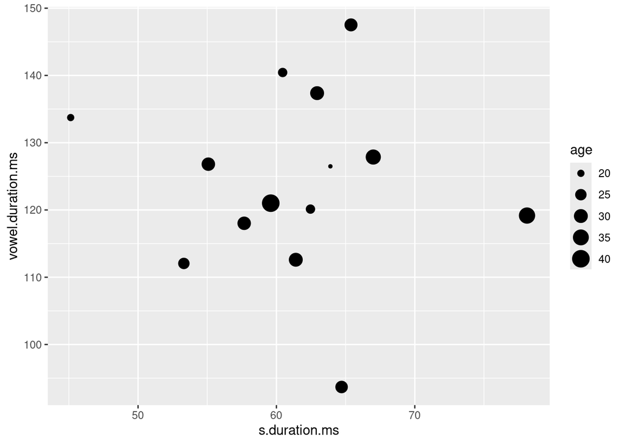

```r
homo |>
  ggplot(aes(s.duration.ms, vowel.duration.ms,
             size = age)) +
  geom_point()
```

Измените цвет точек и добавьте метки:

### Scatterplot: текст

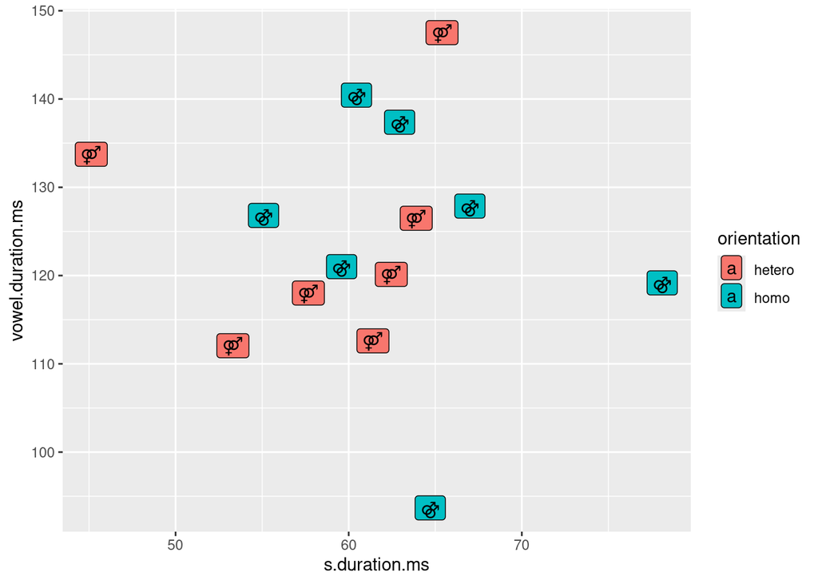

```r
homo |>
  mutate(label = ifelse(orientation == "homo","⚣", "⚤")) |>
  ggplot(aes(s.duration.ms, vowel.duration.ms, label = label, fill = orientation)) +
  geom_label()
```

Используйте цвет (color) вместо заполнения (fill):

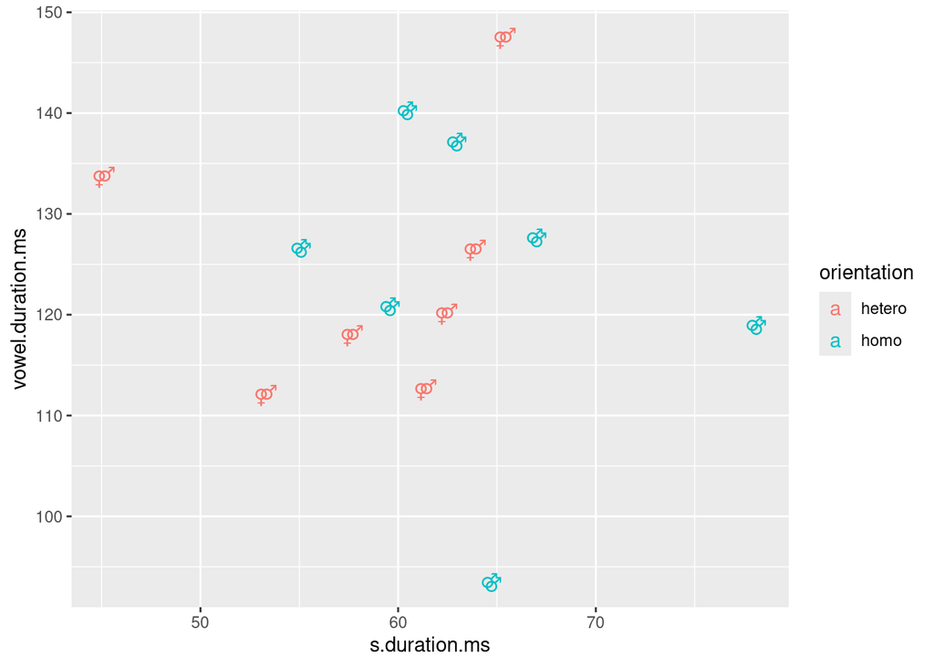

```r
homo |>
  mutate(label = ifelse(orientation == "homo","⚣", "⚤")) |>
  ggplot(aes(s.duration.ms, vowel.duration.ms, label = label, color = orientation)) +
  geom_text()
```

### Title, subtitle, caption

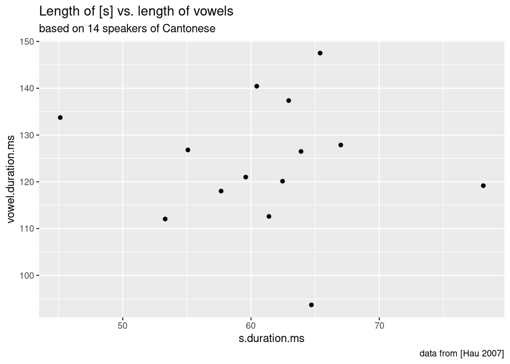

```r
homo |>
  ggplot(aes(s.duration.ms, vowel.duration.ms)) +
  geom_point()+
  labs(title = "Length of [s] vs. length of vowels",
       subtitle = "based on 14 speakers of Cantonese",
       caption = "data from [Hau 2007]")
```

### Axis labels

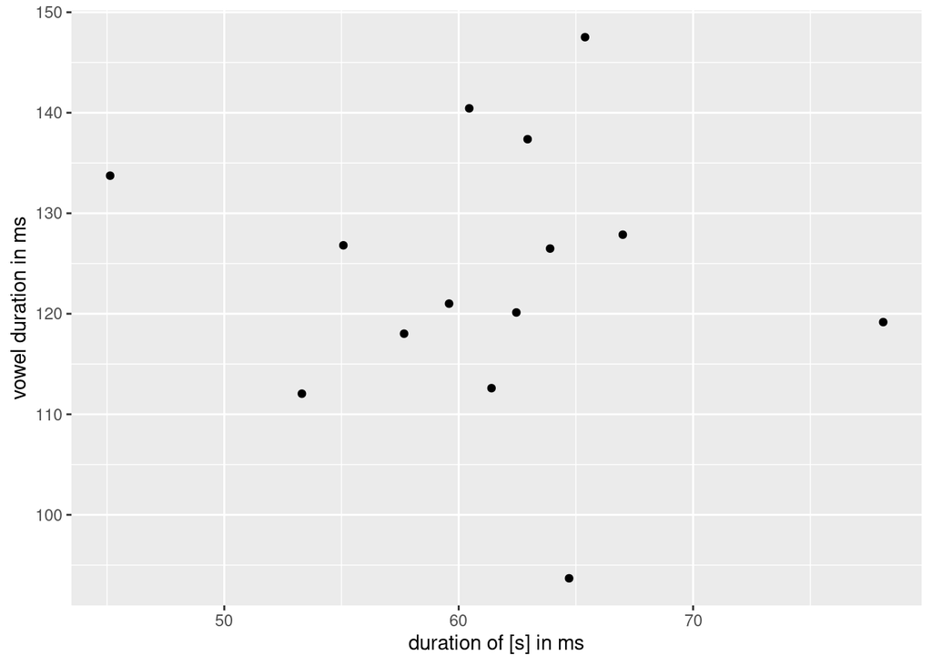

```r
homo |>
  ggplot(aes(s.duration.ms, vowel.duration.ms)) +
  geom_point()+
  xlab("duration of [s] in ms")+
  ylab("vowel duration in ms")
```

### Theme

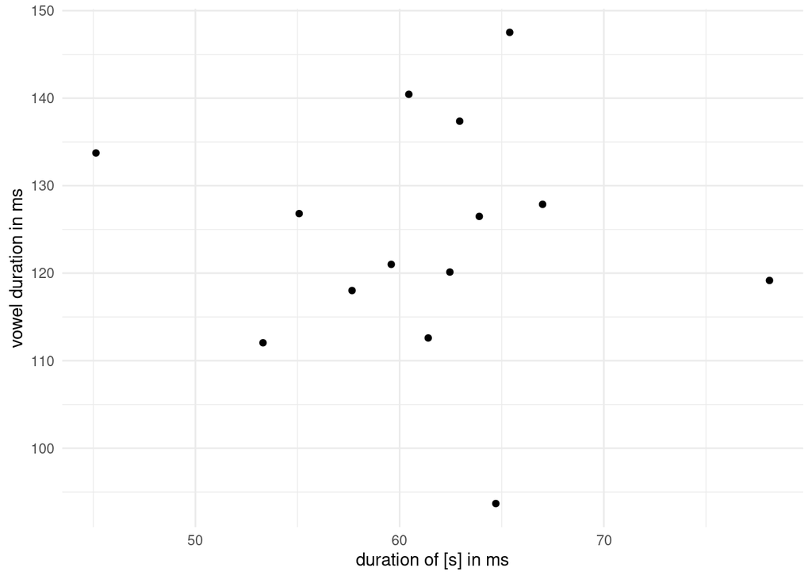

```r
homo |>
  ggplot(aes(s.duration.ms, vowel.duration.ms)) +
  geom_point()+
  xlab("duration of [s] in ms") +
  ylab("vowel duration in ms") +
  theme_minimal()
```

### (Log) scale

```r
freq <- read_csv("https://raw.githubusercontent.com/LingData2019/LingData/master/data/freqrnc2011_1000.csv")
```

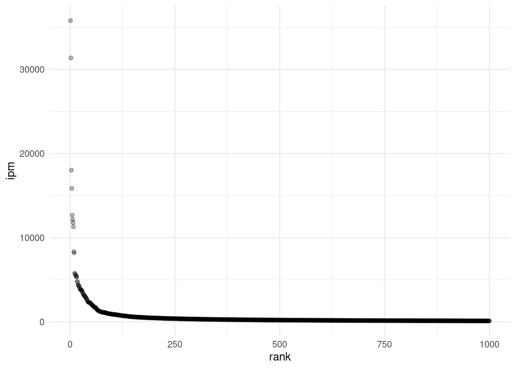

```r
freq |>
  ggplot(aes(rank, freq_ipm)) +
  geom_point(alpha = .3) +
  labs(x = "rank", y = "ipm") +
  theme_minimal()
```

Use scale_y_log10() to transform the y axis:

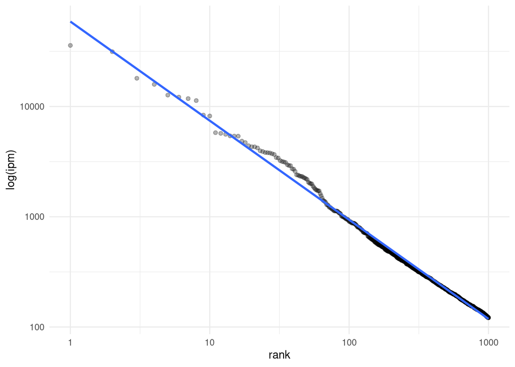

```r
freq |>
  ggplot(aes(1:1000, freq_ipm)) +
  geom_point(alpha = .3) +
  geom_smooth(method=lm)+
  xlab("rank") +
  ylab("log(ipm)") +
  scale_y_log10() +
  scale_x_log10() +
  theme_minimal()
```

### rugs

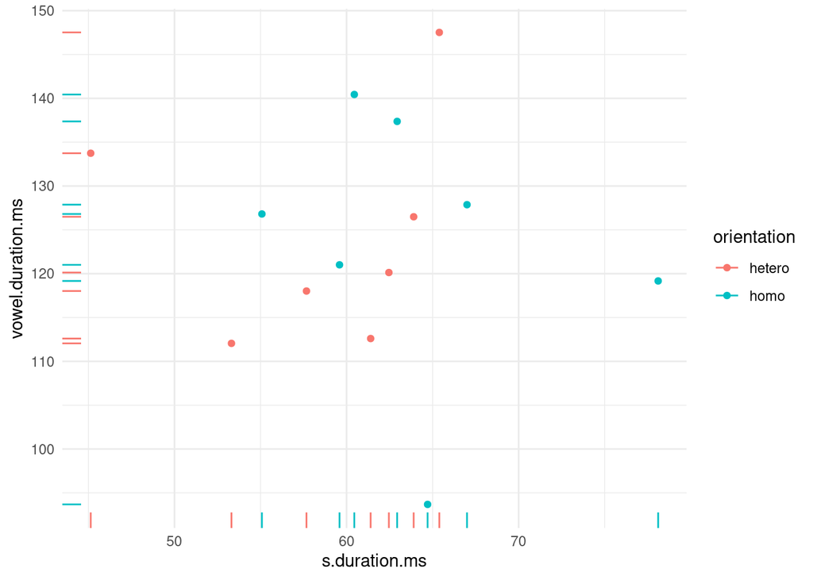

```r
homo |>
  ggplot(aes(s.duration.ms, vowel.duration.ms, color = orientation)) +
  geom_point() +
  geom_rug() +
  theme_minimal()
```

### lines

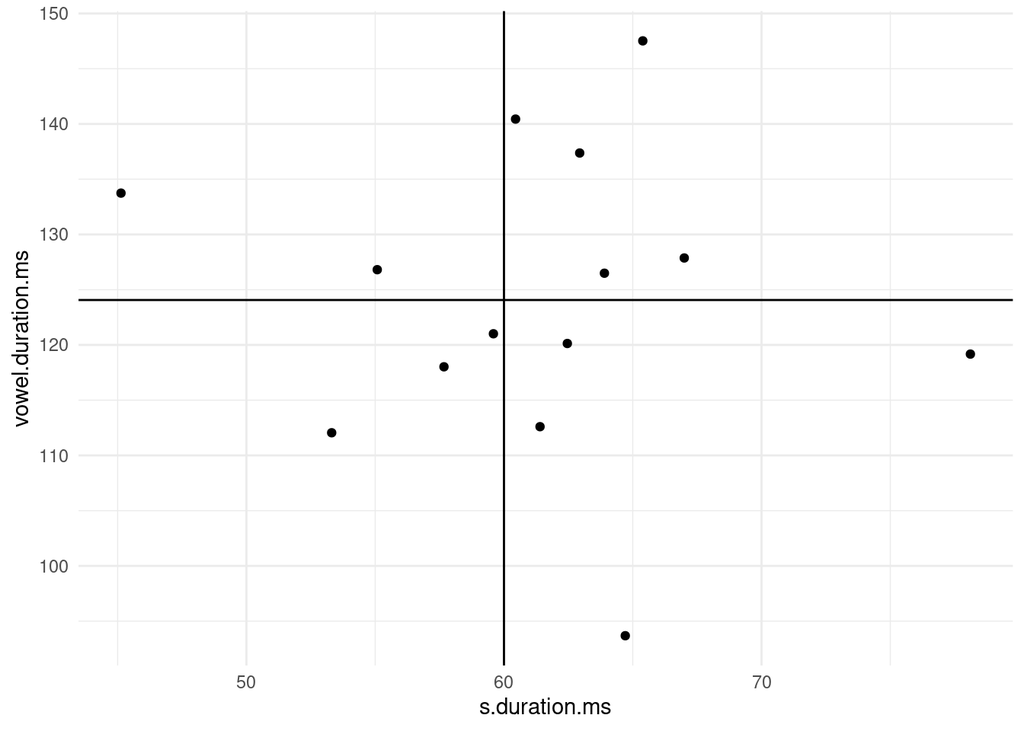

```r
homo |>
  ggplot(aes(s.duration.ms, vowel.duration.ms)) +
  geom_point() +
  geom_hline(yintercept = mean(homo$vowel.duration.ms))+
  geom_vline(xintercept = 60) +
  theme_minimal()
```

Change line types and color:

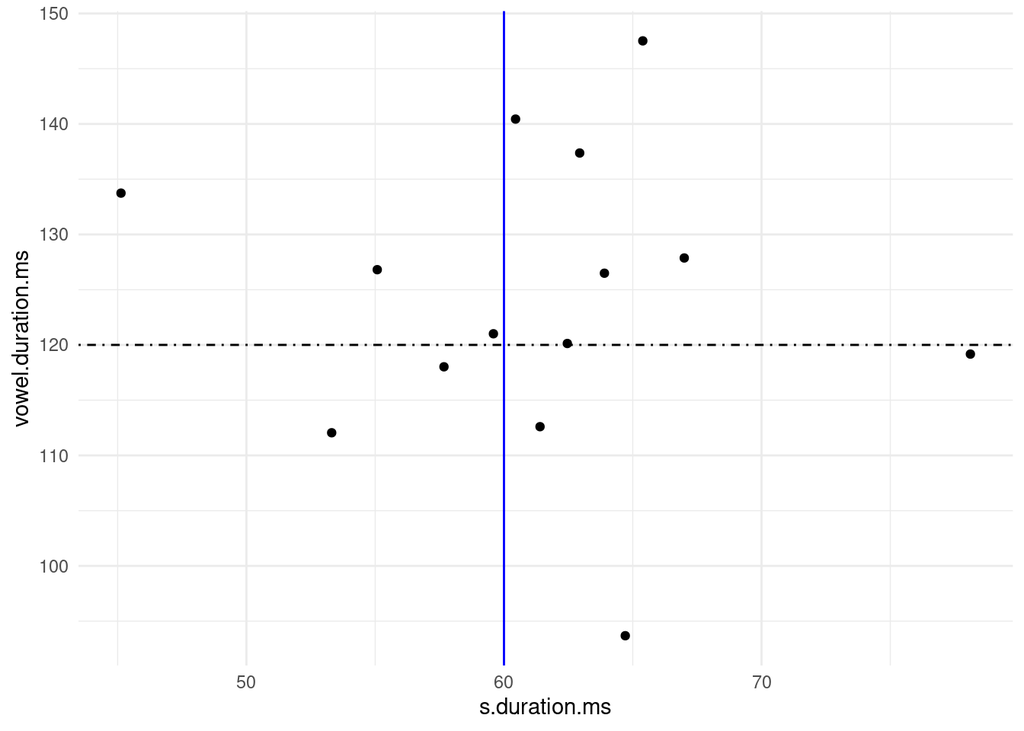

```r
homo |>
  ggplot(aes(s.duration.ms, vowel.duration.ms)) +
  geom_point() +
  geom_hline(yintercept = 120, linetype = 4) +
  geom_vline(xintercept = 60, color = "blue") +
  theme_minimal()
```

### Annotate!

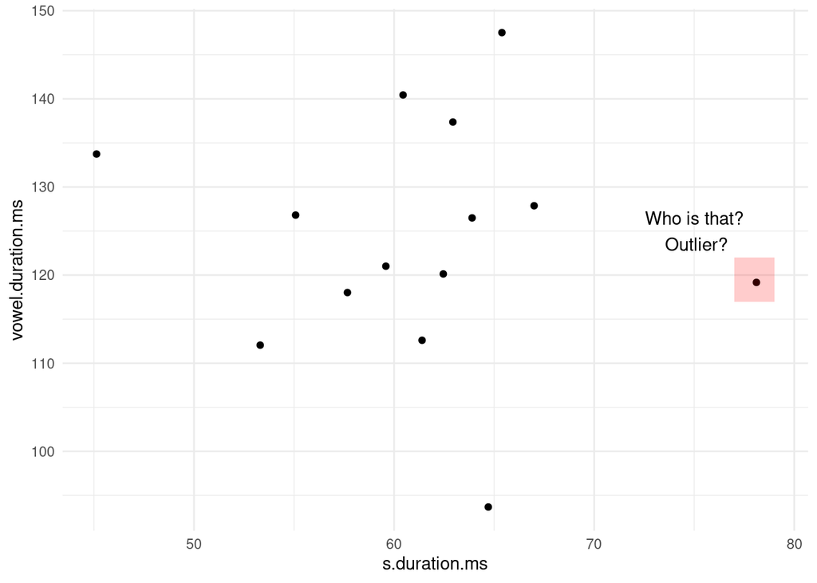

```r
homo |>
  ggplot(aes(s.duration.ms, vowel.duration.ms)) +
  geom_point()+
  annotate(geom = "rect", xmin = 77, xmax = 79,
           ymin = 117, ymax = 122, fill = "red", alpha = 0.2) +
  annotate(geom = "text", x = 75, y = 125,
           label = "Who is that?\n Outlier?") +
  theme_minimal()
```

### Ablines

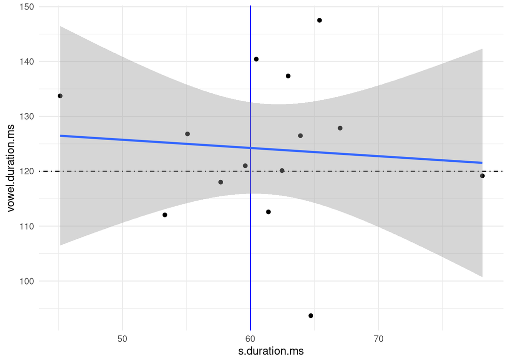

```r
homo |>
  ggplot(aes(s.duration.ms, vowel.duration.ms)) +
  geom_point() +
  geom_hline(yintercept = 120, linetype = 4) +
  geom_vline(xintercept = 60, color = "blue") +
  geom_smooth(method = "lm") +
  theme_minimal()
```

Try geom_smooth() without arguments now!

### Facets

`facet_wrap` – cf. `group_by` in dplyr

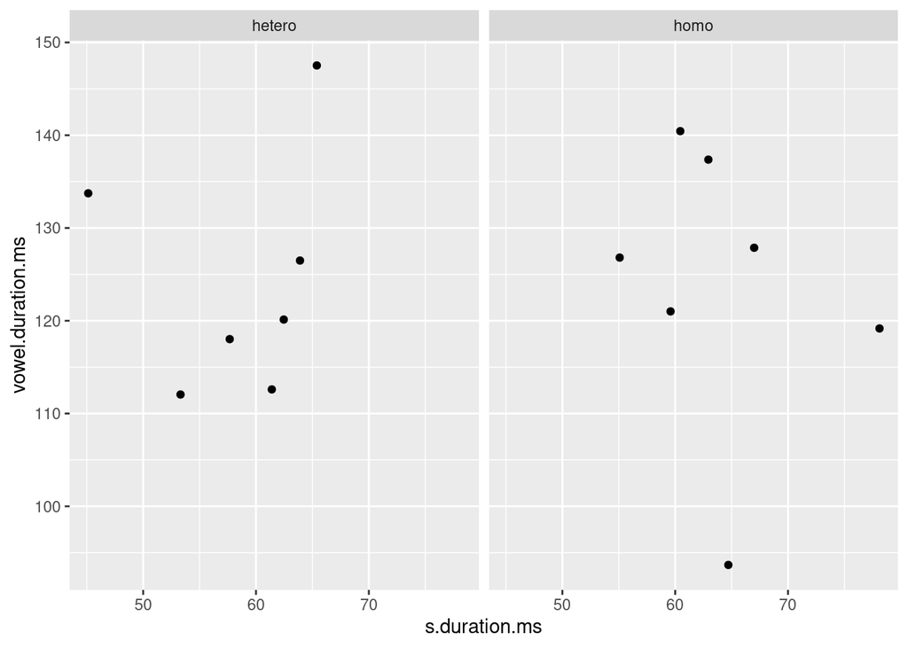

```r
homo |>
  ggplot(aes(s.duration.ms, vowel.duration.ms)) +
  geom_point() +
#  geom_hline(yintercept = 120, linetype = 4) +
#  geom_vline(xintercept = 60, color = "blue") +
#  geom_smooth(method = "lm") +
  facet_wrap(orientation~.)
```

```r
  theme_minimal()
```

[output not shown]

[output not shown]

Another option: `facet_grid`

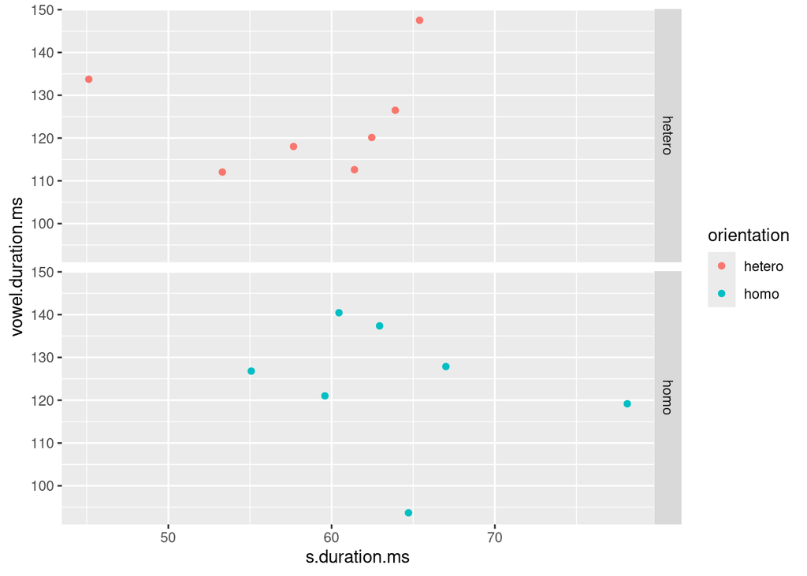

```r
homo |>
  ggplot(aes(s.duration.ms, vowel.duration.ms, colour = orientation, fill = orientation)) +
  geom_point() +
#  geom_hline(yintercept = 120, linetype = 4) +
#  geom_vline(xintercept = 60, color = "blue") +
#  geom_smooth(method = "lm") +
  facet_grid(orientation~.)
```

```r
  theme_minimal()
```

[output not shown]

[output not shown]

Note that `color` and `fill` depend on orientation and are put within the main `aes`

## Categorical data

### Barplots

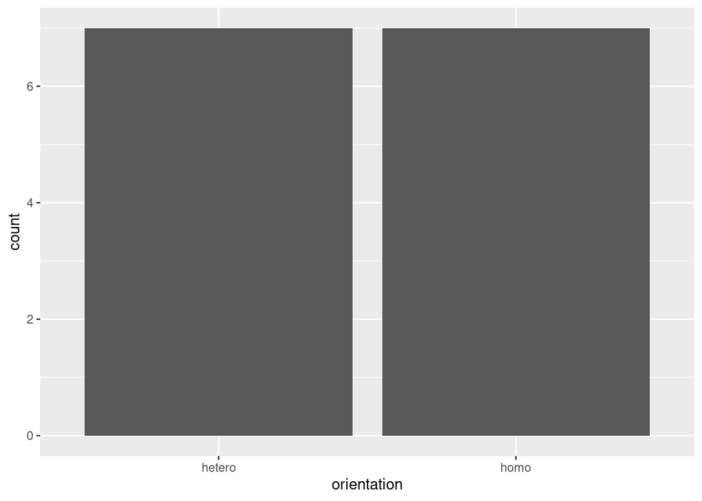

```r
homo |>
  ggplot(aes(orientation)) +
  geom_bar()
```

Make barplots of `age` for each speaker:

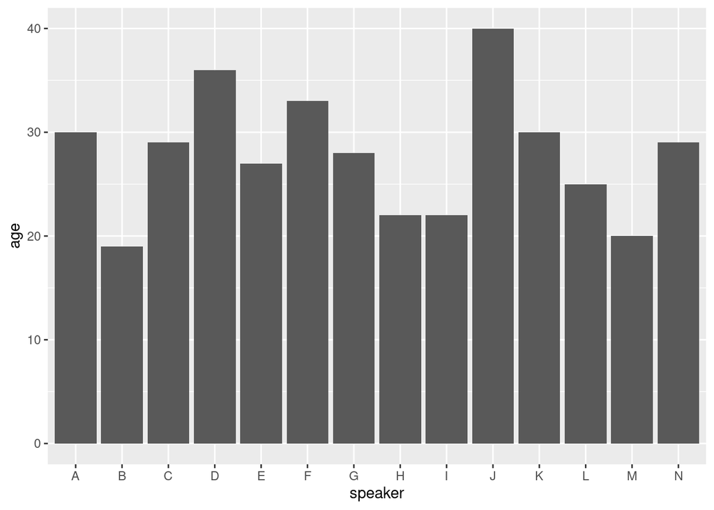

```r
homo |>
  ggplot(aes(speaker, age)) +
  geom_col()
```

Fill bars by orientation:

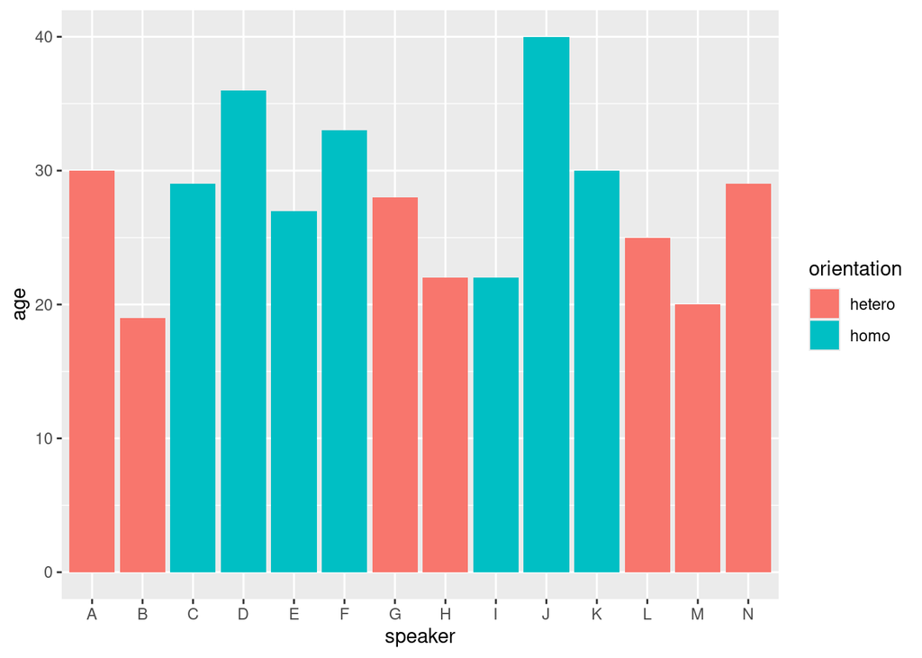

```r
homo |>
  ggplot(aes(speaker, age, fill = orientation)) +
  geom_col()
```

### Aggregated data

The count statistics is use by default here.

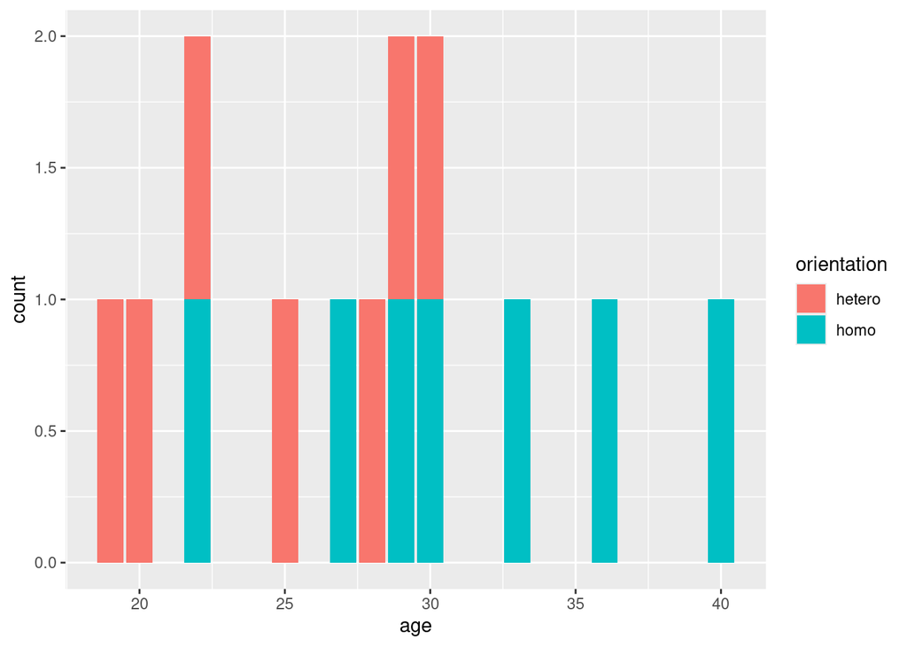

```r
homo |>
  ggplot() +
  geom_bar(aes(age, fill = orientation))
```

Plot all data in one bar:

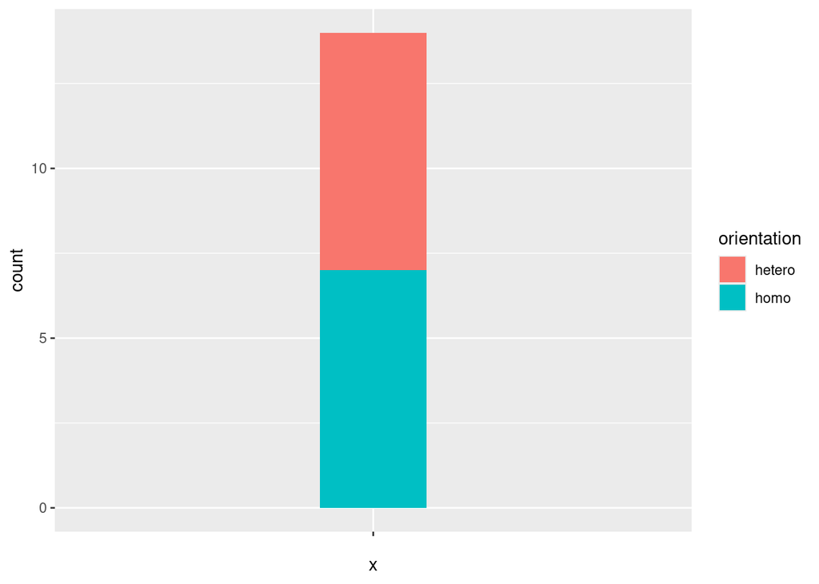

```r
homo |>
  ggplot() +
  geom_bar(aes(x="", fill = orientation), width = 0.2)
```

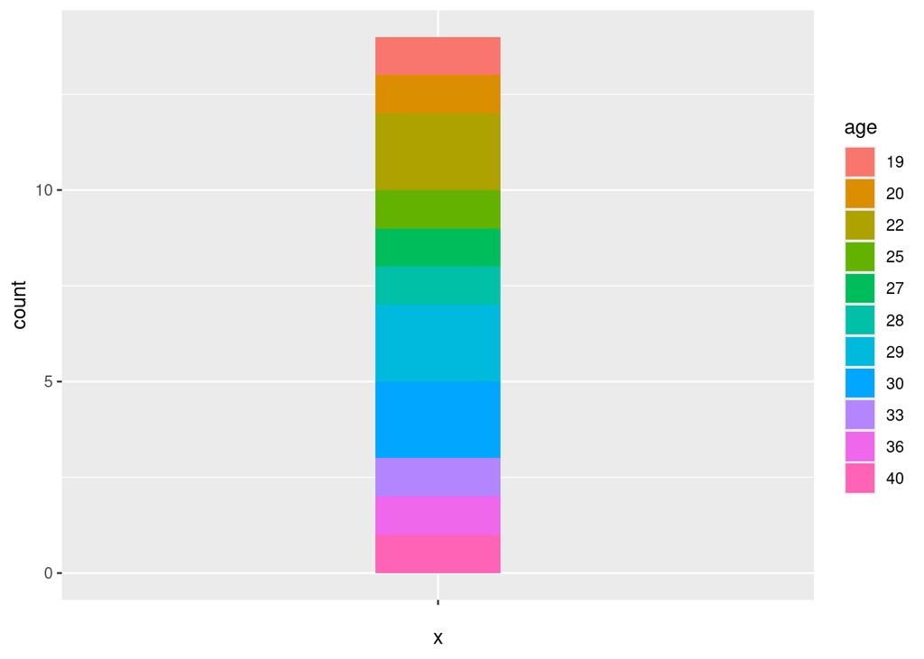

```r
homo |>
  mutate(age = as.factor(age)) |>
  ggplot() +
  geom_bar(aes(x="", fill = age), width = 0.2)
```

NB the width argument of the barplot.

### Piechart

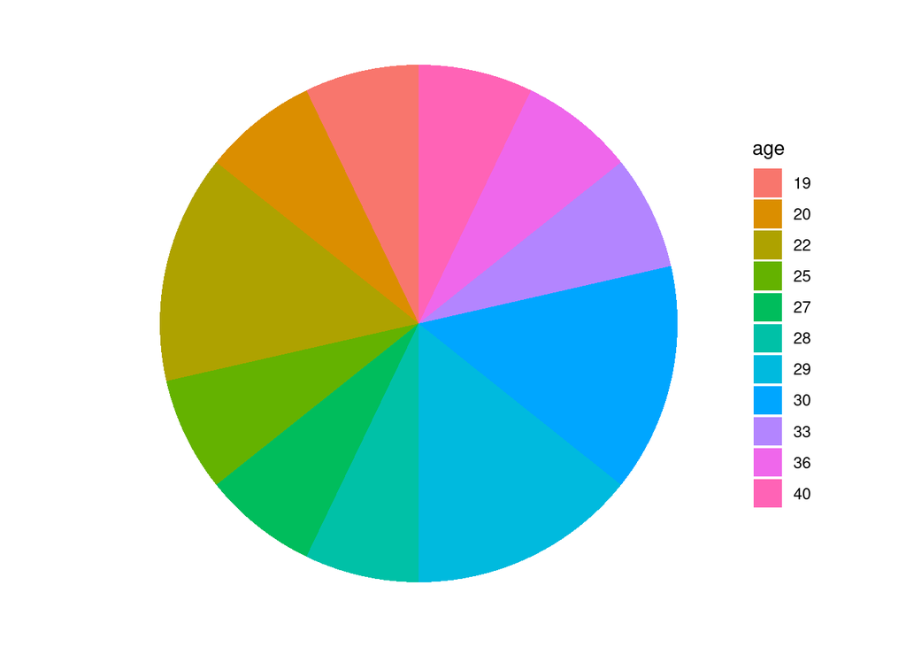

```r
homo |>
  mutate(age = as.factor(age)) |>
  ggplot() +
  geom_bar(aes(x="", fill = age)) +
  coord_polar(theta = "y") +
  theme_void()
```

### Boxplots

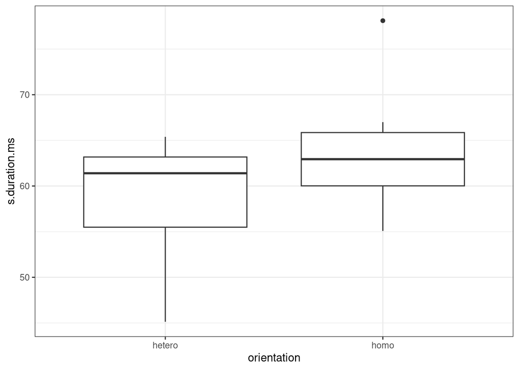

```r
theme_set(theme_bw()) # set black-and-white theme
homo |>
  ggplot(aes(orientation, s.duration.ms)) +
  geom_boxplot()
```

### Boxplots: add points

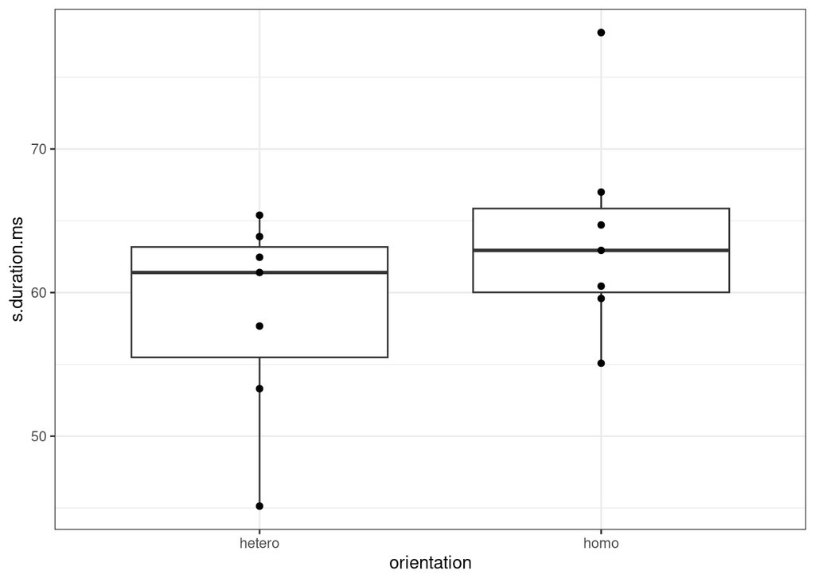

```r
homo |>
  ggplot(aes(orientation, s.duration.ms)) +
  geom_boxplot()+
  geom_point()
```

### Jitter

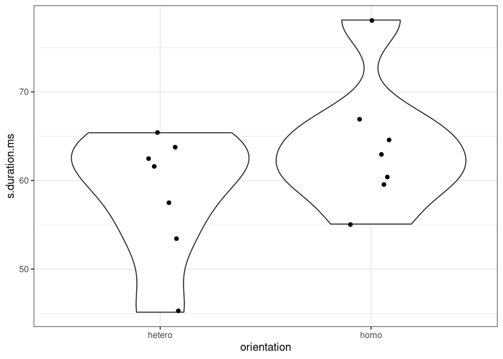

```r
homo |>
  ggplot(aes(orientation, s.duration.ms)) +
  geom_violin() +
  geom_jitter(width = 0.1)
```

### Density plot

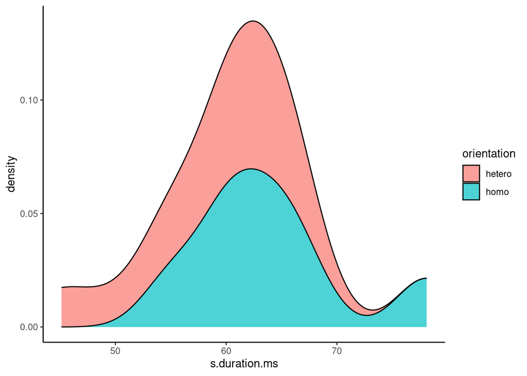

```r
homo |>
  ggplot(aes(x=s.duration.ms, fill=orientation)) +
  geom_density(alpha=0.7, position="stack")+
#  geom_vline()+
#  scale_color_manual(values=c("#999999", "#000000"))+
#   scale_color_grey()+
    theme_classic()
```

Другое решение

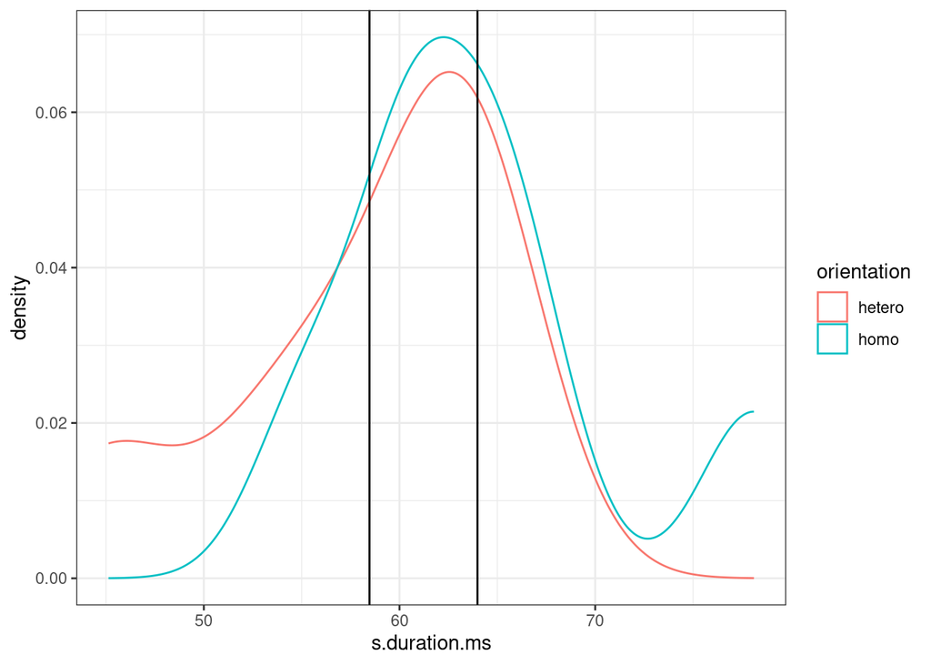

```r
homo |>
  ggplot(aes(x=s.duration.ms, color=orientation)) +
  geom_density() +
  geom_vline(xintercept = mean(homo$s.duration.ms[homo$orientation=="hetero"]))+
  geom_vline(xintercept = mean(homo$s.duration.ms[homo$orientation=="homo"]))
```

### Save as file

```r
pdf("plot.pdf")
homo |>
  ggplot(aes(orientation, s.duration.ms)) +
  geom_boxplot() +
  geom_jitter(width = 0.2)
dev.off()
```

## References:

- Jihui Lee. [Data Visualization with ggplot2](https://www.publichealth.columbia.edu/sites/default/files/media/fdawg_ggplot2.html)
- Raj Kamal Srivastav. [DV using R](https://rpubs.com/honeydwin/Data_visualization_using_R)
- Heather Harvey. [DV for correlation](https://rpubs.com/harveyh1/472257)
[^1]: Кстати, именно функция `subset()` вдохновила Уикхема на создание `filter()`.